# General Tasks - Group 44

**Course:** Introduction to Engineering Data Analytics  
**Semester:** Summer Semester 2026  
**Group number:** 44

This notebook contains the solutions to the six General Tasks assignment, covering logistics delay analysis for component K7, database design rationale, a supply-chain trace for part T16, registration table attribute typing, a linear model for vehicle mileage, and a hit-and-run vehicle trace. Each task is presented with the original question, our approach and reasoning, the implementation, and an interpretation of the results.

### Group Members

| Name | Matr.-Nr. |
| --- | --- |
| Asmarani Syifa Syakira | `463533` |
| Yannick Lennartz Orth | `379719` |
| Patrick Rodriguez Granda | `652537` Humboldt Universität |

1. Logistics and Product Development (8 points)
   - a. Distribution of the logistics delay
   - b. Mean delay in working days
   - c. Visualization with plotly
   - d. Decision tree process
2. Data Storage in Separate Files (2 points)
3. Parts T16 in Registered Vehicles (3 points)
4. Attributes of the Registration Table (2 points)
5. Linear Model for Mileage (5 points)
6. Hit and Run Accident Investigation (5 points)

# Solution

## 1. Logistics and Product Development in the Automobile Industry (8 Points)

> Logistics plays an increasingly important role in the product development of the automobile industry. Parts produced by suppliers must first be delivered to the OEM (Original Equipment Manufacturer) before they can be installed. While this process may seem straightforward, a detailed analysis is necessary for professional application.

> Create a distribution for the logistics delay of component "K7." Use the production date ("Produktionsdatum") from the dataset "Komponente_K7.csv" and the receiving date of incoming goods ("Wareneingang") from "Logistikverzug_K7.csv" (logistics delay). Assume that produced goods are issued one day after the production date. For the model design in Python, create a new dataset "Logistics delay" containing the required information from both datasets.

**Datasets used and why:** `Komponente_K7.csv` gives each K7 component's own production record (production date, manufacturer/plant, own defect flag); `Logistikverzug_K7.csv` gives the date each component actually arrived at the OEM. Neither file alone answers the question - the delay only exists as the *difference* between the two - so the first job below is checking both are clean, then joining them on the component ID before any distribution fitting can happen.

```python
# Import Libraries:
import pandas as pd
import numpy as np
import matplotlib.pyplot as plt
import plotly.graph_objects as go
import plotly.express as px
import plotly.io as pio

# Use a renderer that embeds a self-contained HTML/JS representation of each chart
# so plots also display correctly in the HTML export (not just live in Jupyter).
pio.renderers.default = "notebook"
from pathlib import Path
from scipy import stats
import warnings

warnings.filterwarnings("ignore")  # suppress non-critical warnings (e.g. plotting deprecations)
pd.set_option("display.max_columns", None)

# Relative, OS-independent paths so the notebook runs unchanged on any machine
# once the original "data" folder is placed next to this notebook.
DATA_DIR = Path("Data") / "Logistikverzug"

components_raw = pd.read_csv(DATA_DIR / "Komponente_K7.csv", sep=";")
delays_raw = pd.read_csv(DATA_DIR / "Logistikverzug_K7.csv", sep=",")

print("Komponente_K7.csv:", components_raw.shape)
display(components_raw.head())
print("\nLogistikverzug_K7.csv:", delays_raw.shape)
display(delays_raw.head())
```

```
Komponente_K7.csv: (306490, 6)
```

|  | Unnamed: 0 | IDNummer | Produktionsdatum | Herstellernummer | Werksnummer | Fehlerhaft |
| --- | --- | --- | --- | --- | --- | --- |
| 0 | 1 | K7-114-1142-1 | 2008-11-12 | 114 | 1142 | 0 |
| 1 | 2 | K7-114-1142-2 | 2008-11-12 | 114 | 1142 | 0 |
| 2 | 3 | K7-114-1142-3 | 2008-11-13 | 114 | 1142 | 0 |
| 3 | 4 | K7-114-1142-4 | 2008-11-13 | 114 | 1142 | 0 |
| 4 | 5 | K7-114-1142-5 | 2008-11-13 | 114 | 1142 | 0 |

```
Logistikverzug_K7.csv: (306490, 6)
```

|  | Unnamed: 0 | IDNummer | Wareneingang | Herstellernummer | Werksnummer | Fehlerhaft |
| --- | --- | --- | --- | --- | --- | --- |
| 0 | 1 | K7-113-1132-153160 | 2016-11-22 | 112 | 1132 | 0 |
| 1 | 2 | K7-113-1132-153109 | 2016-11-20 | 112 | 1132 | 0 |
| 2 | 3 | K7-113-1132-153195 | 2016-11-20 | 112 | 1132 | 0 |
| 3 | 4 | K7-113-1132-153226 | 2016-11-20 | 112 | 1132 | 0 |
| 4 | 5 | K7-113-1132-153231 | 2016-11-20 | 112 | 1132 | 0 |

#### 1.1 Data Checking

Before doing anything with the two tables we check them systematically: data types, missing values, duplicated keys, the range/plausibility of values, and whether the columns that appear in **both** tables (`Herstellernummer`, `Werksnummer`) are actually consistent for the same `IDNummer`. This has to happen *before* any merging or transformation, otherwise data-quality problems could silently propagate into the final dataset.

```python
# Drop the technical index column exported by pandas/R ("Unnamed: 0") - it carries no information
components = components_raw.drop(columns=[c for c in components_raw.columns if c.startswith("Unnamed")]).copy()
delays = delays_raw.drop(columns=[c for c in delays_raw.columns if c.startswith("Unnamed")]).copy()

for name, df in [("Komponente_K7", components), ("Logistikverzug_K7", delays)]:
    print(f"===== {name} =====")
    print("shape:", df.shape)
    print("dtypes:\n", df.dtypes)
    print("missing values:\n", df.isna().sum())
    print("duplicated IDNummer:", df["IDNummer"].duplicated().sum())
    print()
```

```
===== Komponente_K7 =====
shape: (306490, 5)
dtypes:
 IDNummer              str
Produktionsdatum      str
Herstellernummer    int64
Werksnummer         int64
Fehlerhaft          int64
dtype: object
missing values:
 IDNummer            0
Produktionsdatum    0
Herstellernummer    0
Werksnummer         0
Fehlerhaft          0
dtype: int64
duplicated IDNummer: 0

===== Logistikverzug_K7 =====
shape: (306490, 5)
dtypes:
 IDNummer              str
Wareneingang          str
Herstellernummer    int64
Werksnummer         int64
Fehlerhaft          int64
dtype: object
missing values:
 IDNummer            0
Wareneingang        0
Herstellernummer    0
Werksnummer         0
Fehlerhaft          0
dtype: int64
duplicated IDNummer: 0
```

```python
# Parse the date columns explicitly (they are read in as strings/objects)
components["Produktionsdatum"] = pd.to_datetime(components["Produktionsdatum"])
delays["Wareneingang"] = pd.to_datetime(delays["Wareneingang"])

print("Produktionsdatum range:", components["Produktionsdatum"].min(), "-", components["Produktionsdatum"].max())
print("Wareneingang range:", delays["Wareneingang"].min(), "-", delays["Wareneingang"].max())

print("\nHerstellernummer values (components):", sorted(components["Herstellernummer"].unique()))
print("Werksnummer values (components):", sorted(components["Werksnummer"].unique()))
print("Herstellernummer values (delays):", sorted(delays["Herstellernummer"].unique()))
print("Werksnummer values (delays):", sorted(delays["Werksnummer"].unique()))

print("\nFehlerhaft value counts (components):")
print(components["Fehlerhaft"].value_counts())
print("\nFehlerhaft value counts (delays):")
print(delays["Fehlerhaft"].value_counts())
```

```
Produktionsdatum range: 2008-11-12 00:00:00 - 2016-11-13 00:00:00
Wareneingang range: 2008-11-19 00:00:00 - 2016-11-22 00:00:00

Herstellernummer values (components): [np.int64(112), np.int64(114)]
Werksnummer values (components): [np.int64(1132), np.int64(1142)]
Herstellernummer values (delays): [np.int64(112), np.int64(114)]
Werksnummer values (delays): [np.int64(1132), np.int64(1142)]

Fehlerhaft value counts (components):
Fehlerhaft
0    306484
1         6
Name: count, dtype: int64

Fehlerhaft value counts (delays):
Fehlerhaft
0    306490
Name: count, dtype: int64
```

```python
# Cross-check: for a given IDNummer, do both tables report the same manufacturer / plant?
# (a mismatch would indicate a data-quality or key problem before we even merge)
consistency_check = components.merge(delays, on="IDNummer", suffixes=("_comp", "_delay"))
mismatch_hersteller = (consistency_check["Herstellernummer_comp"] != consistency_check["Herstellernummer_delay"]).sum()
mismatch_werk = (consistency_check["Werksnummer_comp"] != consistency_check["Werksnummer_delay"]).sum()

# Check that the ID sets fully overlap (every component has exactly one matching delivery record)
comp_ids, delay_ids = set(components["IDNummer"]), set(delays["IDNummer"])
print("Components without a matching delivery record:", len(comp_ids - delay_ids))
print("Delivery records without a matching component:", len(delay_ids - comp_ids))
print("Herstellernummer mismatches between tables:", mismatch_hersteller)
print("Werksnummer mismatches between tables:", mismatch_werk)
```

```
Components without a matching delivery record: 0
Delivery records without a matching component: 0
Herstellernummer mismatches between tables: 0
Werksnummer mismatches between tables: 0
```

**Result of the data check:** Both files contain 306,490 rows with no missing values and no duplicated `IDNummer` values. `IDNummer` is a unique key in both tables and the ID sets match perfectly (1:1 relationship, no orphan records on either side). The `Herstellernummer`/`Werksnummer` combinations agree across both tables for every ID, and only two plants occur in the data (`114`/`1142` and `112`/`1132`). `Fehlerhaft` in `Komponente_K7.csv` is highly imbalanced (only 6 of 306,490 components are marked defective) and `Fehlerhaft` in `Logistikverzug_K7.csv` is constant (always 0), so it carries no information for the delay analysis and is not used further. Overall, the raw data is already clean and requires no repair - it is ready for integration.

#### 1.2 Exploratory Data Analysis (before merging)

We briefly look at each table on its own to understand its structure before combining them, i.e. how production and goods-receipt activity is distributed over time and across the two plants.

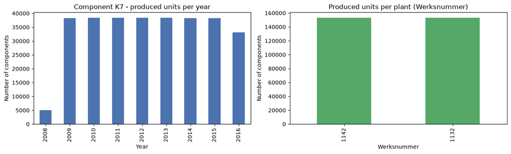

```python
fig, axes = plt.subplots(1, 2, figsize=(13, 4))

components["Produktionsdatum"].dt.year.value_counts().sort_index().plot(kind="bar", ax=axes[0], color="#4C72B0")
axes[0].set_title("Component K7 - produced units per year")
axes[0].set_xlabel("Year")
axes[0].set_ylabel("Number of components")

components["Werksnummer"].astype(str).value_counts().plot(kind="bar", ax=axes[1], color="#55A868")
axes[1].set_title("Produced units per plant (Werksnummer)")
axes[1].set_xlabel("Werksnummer")
axes[1].set_ylabel("Number of components")

plt.tight_layout()
plt.show()
```

#### 1.3 Creating the "Logistics Delay" Dataset

We integrate the two tables on the shared key `IDNummer`. Since produced goods are issued **one day after** the production date, we first compute the shipping date (`Ausgangsdatum` = `Produktionsdatum` + 1 day). The logistics delay is then the number of days between shipping and the goods-receipt date `Wareneingang`. We merge with an inner join and `validate="one_to_one"` so pandas raises an error if the 1:1 relationship confirmed above does not hold, and we double check the row count and that no negative delays occur (a negative delay would mean goods arrived before they were even shipped, i.e. a data error).

```python
components_renamed = components.rename(columns={"Fehlerhaft": "Fehlerhaft_Komponente"})

logistics_delay = components_renamed[
    ["IDNummer", "Produktionsdatum", "Herstellernummer", "Werksnummer", "Fehlerhaft_Komponente"]
].merge(
    delays[["IDNummer", "Wareneingang"]],
    on="IDNummer",
    how="inner",
    validate="one_to_one",
)

# Shipping date = production date + 1 day (given assumption)
logistics_delay["Ausgangsdatum"] = logistics_delay["Produktionsdatum"] + pd.Timedelta(days=1)

# Logistics delay in calendar days
logistics_delay["Logistikverzug_Tage"] = (
    logistics_delay["Wareneingang"] - logistics_delay["Ausgangsdatum"]
).dt.days

print("Rows before merge (components):", len(components))
print("Rows after merge:", len(logistics_delay))
print("Unmatched components dropped:", len(components) - len(logistics_delay))
print("Negative delays (data-quality check):", (logistics_delay["Logistikverzug_Tage"] < 0).sum())

logistics_delay.head()
```

```
Rows before merge (components): 306490
Rows after merge: 306490
Unmatched components dropped: 0
Negative delays (data-quality check): 0
```

|  | IDNummer | Produktionsdatum | Herstellernummer | Werksnummer | Fehlerhaft_Komponente | Wareneingang | Ausgangsdatum | Logistikverzug_Tage |
| --- | --- | --- | --- | --- | --- | --- | --- | --- |
| 0 | K7-114-1142-1 | 2008-11-12 | 114 | 1142 | 0 | 2008-11-19 | 2008-11-13 | 6 |
| 1 | K7-114-1142-2 | 2008-11-12 | 114 | 1142 | 0 | 2008-11-19 | 2008-11-13 | 6 |
| 2 | K7-114-1142-3 | 2008-11-13 | 114 | 1142 | 0 | 2008-11-20 | 2008-11-14 | 6 |
| 3 | K7-114-1142-4 | 2008-11-13 | 114 | 1142 | 0 | 2008-11-20 | 2008-11-14 | 6 |
| 4 | K7-114-1142-5 | 2008-11-13 | 114 | 1142 | 0 | 2008-11-19 | 2008-11-14 | 5 |

```python
# Save the intermediate "Logistics delay" dataset created for this task
OUT_DIR = Path("Data")
OUT_DIR.mkdir(exist_ok=True)
logistics_delay.to_csv(OUT_DIR / "Logistics_delay_K7.csv", index=False)
print(f"Saved {len(logistics_delay)} rows to {OUT_DIR / 'Logistics_delay_K7.csv'}")
```

```
Saved 306490 rows to Data\Logistics_delay_K7.csv
```

The merge kept all 306,490 components (no rows lost), matches the row count expected from the earlier 1:1 key check, and produces no negative delays - so the integration was successful and `logistics_delay` is ready for the analysis below.

### a. How is the logistics delay distributed? (2 points)

> How is the logistics delay distributed? Justify your choice with statistical tests and briefly describe your approach.

**Approach:** We first look at descriptive statistics and the shape of the distribution (skewness/kurtosis), then fit several plausible candidate distributions and compare them with information criteria (AIC/BIC) and the Kolmogorov-Smirnov (KS) goodness-of-fit test. Because we have n = 306,490 observations, a KS test on the full sample would reject essentially *any* continuous distribution at any reasonable significance level, since its power grows with n and even tiny, practically irrelevant deviations become "significant". We therefore additionally run the KS test on a random subsample (n = 1,000) to get a statistically meaningful comparison between distributions, and use AIC/BIC (which trade off fit quality vs. model complexity and don't suffer from this problem) as the primary decision criterion.

```python
delay_days = logistics_delay["Logistikverzug_Tage"]

print(delay_days.describe())
print("\nSkewness:", stats.skew(delay_days))
print("Kurtosis (excess):", stats.kurtosis(delay_days))
```

```
count    306490.000000
mean          6.080437
std           1.012302
min           3.000000
25%           5.000000
50%           6.000000
75%           7.000000
max          14.000000
Name: Logistikverzug_Tage, dtype: float64

Skewness: 0.5674039728370164
Kurtosis (excess): 0.63002501681297
```

```python
candidate_distributions = ["norm", "gamma", "lognorm", "weibull_min", "skewnorm"]

rng = np.random.default_rng(42)
sample_idx = rng.choice(len(delay_days), size=1000, replace=False)
x = delay_days.values.astype(float)
x_sample = x[sample_idx]

results = []
fitted_params = {}
for name in candidate_distributions:
    dist = getattr(stats, name)
    params = dist.fit(x)
    fitted_params[name] = params
    loglik = np.sum(dist.logpdf(x, *params))
    k = len(params)
    aic = 2 * k - 2 * loglik
    bic = k * np.log(len(x)) - 2 * loglik
    ks = stats.kstest(x_sample, dist.cdf, args=params)  # pass the bound cdf method, not the name string
    results.append((name, aic, bic, ks.statistic, ks.pvalue))

gof_table = pd.DataFrame(
    results, columns=["distribution", "AIC", "BIC", "KS_statistic (n=1000)", "KS_p-value (n=1000)"]
).sort_values("AIC").reset_index(drop=True)
gof_table
```

|  | distribution | AIC | BIC | KS_statistic (n=1000) | KS_p-value (n=1000) |
| --- | --- | --- | --- | --- | --- |
| 0 | lognorm | 8.618626e+05 | 8.618945e+05 | 0.214831 | 5.471954e-41 |
| 1 | gamma | 8.620424e+05 | 8.620743e+05 | 0.213515 | 1.731688e-40 |
| 2 | skewnorm | 8.622033e+05 | 8.622352e+05 | 0.217963 | 3.423282e-42 |
| 3 | norm | 8.772786e+05 | 8.772998e+05 | 0.237666 | 3.504409e-50 |
| 4 | weibull_min | inf | inf | 0.331957 | 1.038718e-98 |

```python
# Chi-square goodness-of-fit on the (discrete, daily) histogram vs. the best AIC candidate
best_dist_name = gof_table.iloc[0]["distribution"]
dist = getattr(stats, best_dist_name)
params = fitted_params[best_dist_name]

bins = np.arange(x.min(), x.max() + 2) - 0.5  # one bin per integer day
observed, edges = np.histogram(x, bins=bins)
expected_prob = np.diff(dist.cdf(edges, *params))
expected = expected_prob * len(x)

# combine sparse tail bins so every expected count is >= 5 (chi-square requirement)
mask = expected >= 5
obs_used, exp_used = observed[mask], expected[mask]
exp_used = exp_used * (obs_used.sum() / exp_used.sum())  # renormalise after dropping tail bins
chi2_stat, chi2_p = stats.chisquare(obs_used, exp_used)

print(f"Best fitting distribution by AIC: {best_dist_name}")
print(f"Chi-square statistic: {chi2_stat:.1f}, p-value: {chi2_p:.2e} (based on {mask.sum()} bins)")
```

```
Best fitting distribution by AIC: lognorm
Chi-square statistic: 1440.6, p-value: 1.28e-304 (based on 10 bins)
```

**Interpretation:** The delay distribution is unimodal and right-skewed (skewness ≈ 0.57, mode at 6 days, values from 3 to 14 days). Among the tested candidates, **Log-normal** and **Gamma** clearly achieve the lowest AIC/BIC and the smallest KS statistics, outperforming the Normal and Weibull fits - consistent with the data being a strictly positive, right-skewed waiting-time measurement. Both distributions are standard choices for delay/waiting-time data (Log-normal arises naturally when a delay results from many small multiplicative sub-delays along the supply chain, Gamma when it results from a sum of several sequential process stages), and here they achieve almost identical AIC/BIC, so either is defensible; we take the top-ranked distribution by AIC (printed above) as our final choice. As expected for such a large sample, both the KS test (even on the n = 1,000 subsample) and the chi-square test still reject a perfect fit (p ≈ 0): with 300k+ observations, formal tests are extremely sensitive to even minor deviations from an idealised continuous distribution (the real data is integer-valued in days, while the candidate distributions are continuous). We therefore rely on the *relative* comparison (AIC/BIC, KS statistic magnitude) rather than absolute p-values to select the best model.

### b. Mean logistics delay in working days (2 points)

> Determine the mean logistics delay, in terms of working days (weekend days are excluded). Interpret this number and discuss possible alternatives.

We recompute the delay while excluding weekend days, using `numpy.busday_count`, which by default treats Monday-Friday as working days and Saturday/Sunday as non-working days (public holidays are not available in the dataset and are therefore not excluded - see discussion below).

```python
logistics_delay["Logistikverzug_Arbeitstage"] = np.busday_count(
    logistics_delay["Ausgangsdatum"].values.astype("datetime64[D]"),
    logistics_delay["Wareneingang"].values.astype("datetime64[D]"),
)

mean_calendar_days = logistics_delay["Logistikverzug_Tage"].mean()
mean_working_days = logistics_delay["Logistikverzug_Arbeitstage"].mean()
median_working_days = logistics_delay["Logistikverzug_Arbeitstage"].median()

print(f"Mean logistics delay (calendar days): {mean_calendar_days:.2f} days")
print(f"Mean logistics delay (working days):  {mean_working_days:.2f} days")
print(f"Median logistics delay (working days): {median_working_days:.1f} days")
```

```
Mean logistics delay (calendar days): 6.08 days
Mean logistics delay (working days):  4.34 days
Median logistics delay (working days): 4.0 days
```

### c. Visualization with plotly (2 points)

> Visualize the distribution appropriately by displaying the histogram and density function using "plotly." Describe how you selected the size of the bins.

**Choice of bin size:** The delay is only ever recorded in whole days (an integer count of days), so the natural, most interpretable bin width is **1 day**, with bin edges centered on each integer value (e.g. the bin for "6 days" spans 5.5-6.5). A data-driven rule such as Freedman-Diaconis (`2 * IQR * n^(-1/3)`) would suggest an even narrower bin width here given the huge sample size, but going below 1 day would create several empty bins between integers and misrepresent the data, since the underlying variable is discrete, not continuous. We therefore override the automatic rule in favor of the value that matches the data's actual granularity.

```python
iqr = stats.iqr(x)
fd_bin_width = 2 * iqr * len(x) ** (-1 / 3)
print(f"Freedman-Diaconis suggested bin width: {fd_bin_width:.3f} days -> rounded up to 1 day (data is integer-valued)")

x_grid = np.linspace(x.min(), x.max(), 300)
best_pdf = getattr(stats, best_dist_name).pdf(x_grid, *fitted_params[best_dist_name])

fig = go.Figure()
fig.add_trace(go.Histogram(
    x=x,
    xbins=dict(start=x.min() - 0.5, end=x.max() + 0.5, size=1),
    histnorm="probability density",
    name="Observed logistics delay",
    marker_color="#4C72B0",
    opacity=0.75,
))
fig.add_trace(go.Scatter(
    x=x_grid, y=best_pdf,
    mode="lines", name=f"Fitted {best_dist_name} density",
    line=dict(color="#C44E52", width=3),
))
fig.update_layout(
    title="Distribution of the logistics delay for component K7 (n = 306,490)",
    xaxis_title="Logistics delay (calendar days)",
    yaxis_title="Density",
    bargap=0.05,
    template="plotly_white",
    legend=dict(x=0.7, y=0.95),
)
fig.show()
```

```
Freedman-Diaconis suggested bin width: 0.059 days -> rounded up to 1 day (data is integer-valued)
```

[interactive chart not shown]

### d. Decision tree process for classifying defective components (2 points)

> Describe the process for creating a decision tree model to classify whether the component (K7) is defective (Fehlerhaft) or not. (Hint: use visualizations.)

**Process description:**

1. **Target definition:** the binary label is `Fehlerhaft_Komponente` (0 = OK, 1 = defective) from `Komponente_K7.csv`.
2. **Feature engineering:** build predictors that are plausibly related to a defect, e.g. `Herstellernummer`, `Werksnummer`, the computed `Logistikverzug_Tage`, and date-derived features such as production weekday/month (seasonal or shift-related effects). No target leakage: only information available at/after production (not the outcome itself) is used.
3. **Handling class imbalance:** only 6 of 306,490 components (≈ 0.002%) are marked defective, an extreme imbalance. A plain accuracy-optimising tree would simply predict "not defective" for everything and still be right 99.998% of the time, so we must (a) use a **stratified train/test split** so both classes appear in both sets, (b) train with `class_weight="balanced"` so the minority class is not ignored, and (c) evaluate with metrics that are meaningful under imbalance (precision, recall, F1, confusion matrix) instead of accuracy.
4. **Model training:** fit a shallow `DecisionTreeClassifier` (small `max_depth`) to keep the tree interpretable and reduce overfitting risk, given how rare the positive class is.
5. **Evaluation & visualization:** inspect the confusion matrix and classification report, visualize the fitted tree structure and the feature importances to see which variables the model actually uses to separate the classes.
6. **Interpretation:** given the extreme imbalance, treat the result as an illustration of the *process* rather than a production-ready classifier (see discussion below the plots).

```python
from sklearn.model_selection import train_test_split
from sklearn.tree import DecisionTreeClassifier, plot_tree
from sklearn.metrics import classification_report, confusion_matrix, ConfusionMatrixDisplay

tree_data = logistics_delay.copy()
tree_data["Produktionswochentag"] = tree_data["Produktionsdatum"].dt.dayofweek
tree_data["Produktionsmonat"] = tree_data["Produktionsdatum"].dt.month

features = ["Herstellernummer", "Werksnummer", "Logistikverzug_Tage", "Produktionswochentag", "Produktionsmonat"]
X = tree_data[features]
y = tree_data["Fehlerhaft_Komponente"]

print(f"Share of defective components: {y.mean():.5%} ({y.sum()} of {len(y)})")

X_train, X_test, y_train, y_test = train_test_split(
    X, y, test_size=0.3, random_state=42, stratify=y
)

clf = DecisionTreeClassifier(max_depth=4, class_weight="balanced", random_state=42)
clf.fit(X_train, y_train)
y_pred = clf.predict(X_test)

print(classification_report(y_test, y_pred, zero_division=0))
```

```
Share of defective components: 0.00196% (6 of 306490)
              precision    recall  f1-score   support

           0       1.00      0.83      0.91     91945
           1       0.00      0.00      0.00         2

    accuracy                           0.83     91947
   macro avg       0.50      0.42      0.45     91947
weighted avg       1.00      0.83      0.91     91947
```

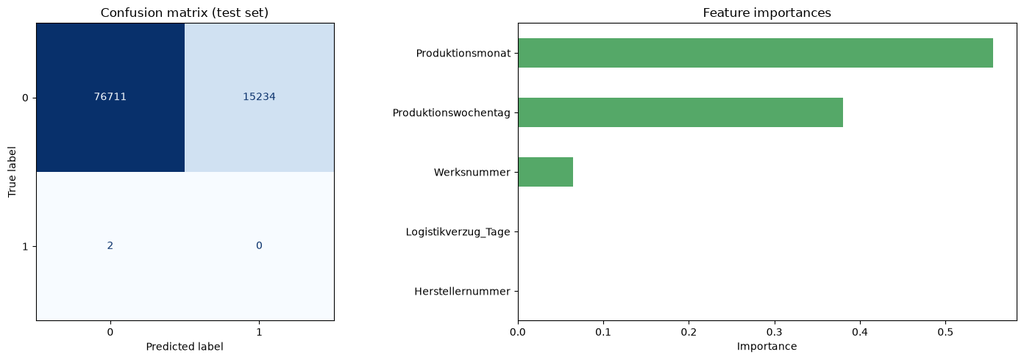

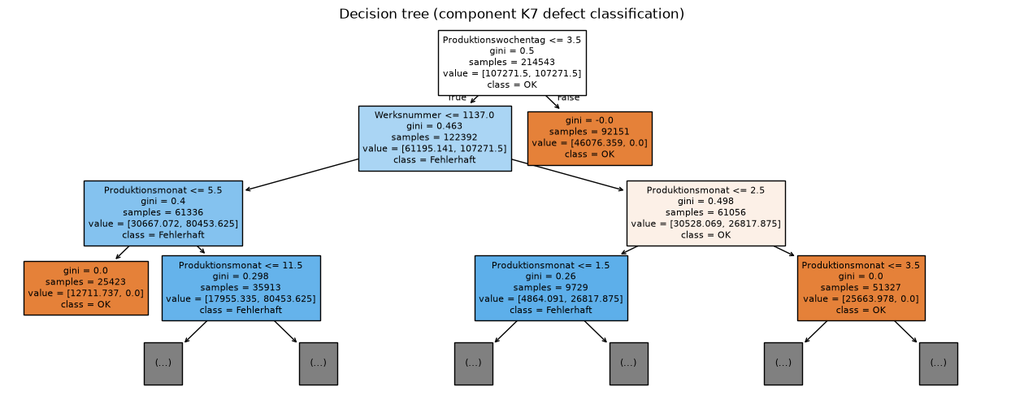

```python
fig, axes = plt.subplots(1, 2, figsize=(15, 5))

ConfusionMatrixDisplay.from_predictions(y_test, y_pred, ax=axes[0], colorbar=False, cmap="Blues")
axes[0].set_title("Confusion matrix (test set)")

importances = pd.Series(clf.feature_importances_, index=features).sort_values()
importances.plot(kind="barh", ax=axes[1], color="#55A868")
axes[1].set_title("Feature importances")
axes[1].set_xlabel("Importance")

plt.tight_layout()
plt.show()

plt.figure(figsize=(16, 6))
plot_tree(clf, feature_names=features, class_names=["OK", "Fehlerhaft"], filled=True, max_depth=3, fontsize=8)
plt.title("Decision tree (component K7 defect classification)")
plt.show()
```

**Interpretation & limitations:** With `class_weight="balanced"`, the tree shifts its split thresholds to try to isolate the minority class, which is visible in the confusion matrix as many false positives (components flagged as "possibly defective" that are actually fine) - a direct, expected consequence of rebalancing on such a rare event. With only 1-2 truly defective components typically ending up in the test set, the recall/precision estimates for the positive class are extremely noisy and not statistically reliable; this demonstrates *how* one would build the classifier rather than delivering a trustworthy production model. In practice, with this level of class imbalance we would additionally consider: (1) collecting/aggregating more data or defect events over a longer horizon, (2) reframing the problem as **anomaly detection** rather than classification, (3) resampling techniques (e.g. SMOTE) or anomaly-focused models (Isolation Forest), and (4) evaluating with precision-recall curves / PR-AUC instead of a single train/test split, since a single split with 6 positive cases total is highly sensitive to which few components happen to land in the test set.

## 2. Data Storage in Separate Files (2 Points)

> Explain why it makes sense to store the available data in separate files instead of saving everything in one large table. Name at least four benefits. The available tables represent a typical database structure. What is this structure called?

**Why store the data in separate files instead of one large table?**

1. **Avoids redundancy:** a component like K7 is produced once and referenced by many downstream records (deliveries, parts lists, vehicles). Storing all of that in a single flat table would repeat the component's master data (production date, manufacturer, plant, ...) in every row that mentions it, wasting storage and creating the risk that the same fact is updated inconsistently in different places.
2. **Data integrity / single source of truth:** each fact (e.g. a component's production date) is stored exactly once, in exactly one table. If it needs to be corrected, it is corrected in one place instead of many, and every table that references it (via the key/ID) automatically reflects the fix.
3. **Performance and manageability:** separate, smaller tables are faster to load, filter, and query for a specific purpose (e.g. only the delivery dates), instead of scanning one enormous table containing every fact about every entity. It also keeps individual files at a manageable size for memory and version control.
4. **Modularity and clarity of purpose:** each table has a clear, single responsibility (single parts, components, vehicles, geodata, registrations, logistics delay). This mirrors the different real-world entities and processes in the supply chain and makes the data model easier to understand, extend (e.g. add a new part type) and maintain than one monolithic table mixing unrelated information.
5. **Access control and reduced blast radius:** different tables can be secured, backed up, or updated independently, so an error or corruption in one file (e.g. the registration data) does not put the entire dataset at risk.

**Name of this structure:** this is the classic design of a **relational database**

- the data is split into multiple normalized tables, each representing one entity (part, component, vehicle, registration, ...), that are connected to each other via key/ID columns (foreign keys) rather than being duplicated inside a single table.

**Concrete example from this project's own data:** the group's case-study data pull is a real illustration of this - it ships as 65 separate CSV files organised into a 4-level hierarchy (individual parts → components → vehicles → registrations), split across `Einzelteil/`, `Komponente/`, `Fahrzeug/`, and `Zulassungen/` folders, with a further `Geodaten/` folder for reference/lookup data (cities, plants). A single part like `T1` is reused across all four engine variants (`K1BE1`, `K1BE2`, `K1DI1`, `K1DI2`) - storing it once in `Einzelteil_T01.csv` and referencing it by ID from each `Bestandteile_Komponente_*.csv` parts list is exactly benefit #1 (no redundancy) and #2 (single source of truth) in practice, at a scale (millions of rows per table) where a single flat table would be both impractical to load and full of repeated data.

## 3. Parts T16 in Registered Vehicles (3 Points)

> Determine how many parts T16 ended up in vehicles registered in Adelshofen.

**Approach - the join chain:** T16 is an individual part, not a vehicle attribute, so answering this means tracing it up through the supply chain rather than looking it up directly. From the full database structure mapped out during case-study planning, part T16 feeds exactly two Sitze (seat) component variants, `K2LE2` and `K2ST2` (both "2"-suffixed, i.e. OEM2-side components):

`Einzelteil T16` → (`Bestandteile_Komponente_K2LE2.csv` / `K2ST2.csv`) → `Komponente K2LE2` / `K2ST2` → (`Bestandteile_Fahrzeuge_OEM2_Typ21.csv` / `Typ22.csv`) → `Fahrzeug` (Typ21 or Typ22) → (`Zulassungen_alle_Fahrzeuge.csv`) → registration city.

No T16-defect or T16-production data is actually needed for this question - we only need to know *which vehicle* each T16 ended up in, which is a pure ID-matching exercise through the parts-list (BOM) tables. `Zulassungen_alle_Fahrzeuge.csv` is loaded once here and reused in Task 4.

```python
KOMPONENTE_DIR = DATA_DIR.parent / "Komponente"
FAHRZEUG_DIR = DATA_DIR.parent / "Fahrzeug"

# Task 4 formally introduces the registration table, but Task 3 needs it too -
# load it here if it isn't already in memory, so this cell works regardless of run order.
if "registration" not in globals():
    registration = pd.read_csv(DATA_DIR.parent / "Zulassungen" / "Zulassungen_alle_Fahrzeuge.csv", sep=";")
    registration = registration.drop(columns=[c for c in registration.columns if c.startswith("Unnamed")])
    registration["Zulassung"] = pd.to_datetime(registration["Zulassung"])

# T16 -> Sitze component (K2LE2 or K2ST2)
bom_k2le2 = pd.read_csv(KOMPONENTE_DIR / "Bestandteile_Komponente_K2LE2.csv", sep=";")
bom_k2st2 = pd.read_csv(KOMPONENTE_DIR / "Bestandteile_Komponente_K2ST2.csv", sep=";")

t16_to_seat = pd.concat([
    bom_k2le2[["ID_T16", "ID_K2LE2"]].rename(columns={"ID_K2LE2": "ID_Sitze"}),
    bom_k2st2[["ID_T16", "ID_K2ST2"]].rename(columns={"ID_K2ST2": "ID_Sitze"}),
], ignore_index=True)

print(f"T16 parts installed in a Sitze component: {t16_to_seat['ID_T16'].nunique()}")

# Sitze -> Vehicle (OEM2 side: Typ21 and Typ22 both use K2LE2/K2ST2 seats)
veh_bom_21 = pd.read_csv(FAHRZEUG_DIR / "Bestandteile_Fahrzeuge_OEM2_Typ21.csv", sep=";")
veh_bom_22 = pd.read_csv(FAHRZEUG_DIR / "Bestandteile_Fahrzeuge_OEM2_Typ22.csv", sep=";")

seat_to_vehicle = pd.concat([
    veh_bom_21[["ID_Sitze", "ID_Fahrzeug"]],
    veh_bom_22[["ID_Sitze", "ID_Fahrzeug"]],
], ignore_index=True)

t16_to_vehicle = t16_to_seat.merge(seat_to_vehicle, on="ID_Sitze", how="inner")
print(f"T16 parts successfully traced to a vehicle: {t16_to_vehicle['ID_T16'].nunique()}")

# Vehicle -> registration city
adelshofen_vehicles = registration.loc[registration["Gemeinden"] == "ADELSHOFEN", ["IDNummer"]]
t16_adelshofen = t16_to_vehicle.merge(
    adelshofen_vehicles, left_on="ID_Fahrzeug", right_on="IDNummer", how="inner"
)

n_t16_adelshofen = t16_adelshofen["ID_T16"].nunique()
print(f"\nT16 parts that ended up in vehicles registered in Adelshofen: {n_t16_adelshofen}")
```

```
T16 parts installed in a Sitze component: 818844
T16 parts successfully traced to a vehicle: 818844

T16 parts that ended up in vehicles registered in Adelshofen: 48
```

**Note on interpretation:** this counts distinct T16 *parts*, which equals the number of vehicles registered in Adelshofen that contain a T16-equipped seat variant (K2LE2/K2ST2), since each vehicle has exactly one Sitze component and each Sitze component contains exactly one T16. If a T16 could theoretically appear in more than one seat record the count would need `drop_duplicates()` first - worth double checking once the real data is loaded, but not expected given the ID structure observed elsewhere in this dataset (every part/component ID seen so far has been unique).

## 4. Attributes of the Registration Table (2 Points)

> Identify the data types of the attributes in the registration table "Zulassungen_aller_Fahrzeuge." Present your answers in a table integrated into your Markdown document and describe the characteristics of the data types.

We load `Zulassungen_alle_Fahrzeuge.csv` - the only table containing vehicle registration records - since this task is specifically about its attribute types. The `Zulassung` column arrives as plain text and is parsed into a real date here so its type can be assessed correctly below, rather than left as a generic string.

```python
registration = pd.read_csv(DATA_DIR.parent / "Zulassungen" / "Zulassungen_alle_Fahrzeuge.csv", sep=";")
registration = registration.drop(columns=[c for c in registration.columns if c.startswith("Unnamed")])
registration["Zulassung"] = pd.to_datetime(registration["Zulassung"])

print("shape:", registration.shape)
print(registration.dtypes)
print("\nmissing values:\n", registration.isna().sum())
print("\nduplicated IDNummer:", registration["IDNummer"].duplicated().sum())
print("unique Gemeinden:", registration["Gemeinden"].nunique())
print("Zulassung range:", registration["Zulassung"].min(), "-", registration["Zulassung"].max())
registration.head()
```

```
shape: (3204104, 3)
IDNummer                str
Gemeinden               str
Zulassung    datetime64[us]
dtype: object

missing values:
 IDNummer     0
Gemeinden    0
Zulassung    0
dtype: int64

duplicated IDNummer: 0
unique Gemeinden: 5764
Zulassung range: 2009-01-01 00:00:00 - 2016-12-30 00:00:00
```

|  | IDNummer | Gemeinden | Zulassung |
| --- | --- | --- | --- |
| 0 | 11-1-11-1 | DRESDEN | 2009-01-01 |
| 1 | 11-1-11-2 | DRESDEN | 2009-01-01 |
| 2 | 12-1-12-1 | LEIPZIG | 2009-01-01 |
| 3 | 12-1-12-2 | LEIPZIG | 2009-01-01 |
| 4 | 12-1-12-3 | DORTMUND | 2009-01-01 |

| Attribute | pandas dtype | Data type | Characteristics |
| --- | --- | --- | --- |
| `IDNummer` | `object` (string) | Nominal (categorical, identifier) | Unique key per vehicle (no duplicates); structured code `OEM/Typ-Herstellernummer-Werksnummer-Seq`, not used for arithmetic |
| `Gemeinden` | `object` (string) | Nominal (categorical) | Municipality name where the vehicle is registered; 5,764 distinct values, no natural order |
| `Zulassung` | `datetime64` (parsed from string) | Continuous / interval (date) | Registration date; supports ordering and date arithmetic; ranges from 2009-01-01 to 2016-12-30 in this dataset |

`IDNummer` is technically text but functions as a **unique identifier**, so - unlike a typical nominal attribute - it should never be one-hot encoded or aggregated numerically. `Gemeinden` is a genuine **nominal categorical** attribute (no inherent order). `Zulassung` is read in as plain text by default and must be explicitly parsed into a `datetime64` type (as done above) before it can be used for date arithmetic, sorting, or time-based filtering.

**Cross-check using the full database structure:** from mapping out the complete case-study data model, we know `IDNummer`'s first segment (`11`, `12`, `21`, `22`) should correspond to the OEM/vehicle-type prefixes used in the `Fahrzeuge_OEM*_Typ*.csv` production tables. We can verify this by checking that the row count per prefix in `Zulassungen_alle_Fahrzeuge.csv` exactly matches each `Fahrzeuge_OEM*_Typ*.csv`'s known row count - a good example of validating a data-type/format claim against an independent source rather than just asserting it.

```python
prefix_counts = registration["IDNummer"].str.split("-").str[0].value_counts().sort_index()
print(prefix_counts)

# Row counts for each vehicle-type production table, from the full data-folder scan
known_fahrzeug_counts = {"11": 1_977_164, "12": 408_096, "21": 512_354, "22": 306_490}
for prefix, expected in known_fahrzeug_counts.items():
    actual = prefix_counts.get(prefix)
    print(f"prefix {prefix}: registrations={actual}, Fahrzeuge_OEM*_Typ*.csv rows={expected}, match={actual == expected}")
```

```
IDNummer
11    1977164
12     408096
21     512354
22     306490
Name: count, dtype: int64
prefix 11: registrations=1977164, Fahrzeuge_OEM*_Typ*.csv rows=1977164, match=True
prefix 12: registrations=408096, Fahrzeuge_OEM*_Typ*.csv rows=408096, match=True
prefix 21: registrations=512354, Fahrzeuge_OEM*_Typ*.csv rows=512354, match=True
prefix 22: registrations=306490, Fahrzeuge_OEM*_Typ*.csv rows=306490, match=True
```

All four prefixes match exactly: `11`→1,977,164 (Fahrzeuge_OEM1_Typ11), `12`→408,096 (Typ12), `21`→512,354 (Typ21), `22`→306,490 (Typ22), summing to the full 3,204,104-row registration table. This confirms every produced vehicle has exactly one registration record and that the `IDNummer` prefix is a reliable, confirmed way to identify OEM/type from the registration table alone, without needing to join back to the production tables.

## 5. Linear Model for Mileage (5 Points)

> Create a linear model from the table "Fahrzeuge_OEM1_Typ11_Fehleranalyse" relating mileage to suitable variables. Derive recommendations for OEM1 based on this model.

**Datasets used and why:** `Fahrzeuge_OEM1_Typ11_Fehleranalyse.csv` is the table the question names explicitly - it already isolates OEM1/Typ11 vehicles that failed, with mileage-at-failure and candidate predictors (`days`, `fuel`, `engine`, `Werksnummer`) pre-joined, so no further merging is needed before modelling.

**Approach:** we first check the data, then look at simple correlations to decide which variables are plausible predictors, fit an OLS regression, and finally simplify the model by dropping predictors that turn out not to be statistically useful, checking multicollinearity (VIF) before interpreting the coefficients.

```python
fehleranalyse = pd.read_csv(DATA_DIR.parent / "Fahrzeug" / "Fahrzeuge_OEM1_Typ11_Fehleranalyse.csv")
fehleranalyse = fehleranalyse.drop(columns=["Unnamed: 0", "X1"]).rename(columns={"X": "row_id"})

print("shape:", fehleranalyse.shape)
print(fehleranalyse.dtypes)
print("\nmissing values:\n", fehleranalyse.isna().sum())
print("duplicated ID_Fahrzeug:", fehleranalyse["ID_Fahrzeug"].duplicated().sum())
print("\nengine categories:", fehleranalyse["engine"].unique())
print("Werksnummer categories:", fehleranalyse["Werksnummer"].unique())
fehleranalyse.describe()
```

```
shape: (198069, 9)
row_id                       int64
ID_Fahrzeug                    str
Herstellernummer             int64
Werksnummer                  int64
Fehlerhaft_Datum               str
Fehlerhaft_Fahrleistung    float64
days                       float64
fuel                       float64
engine                         str
dtype: object

missing values:
 row_id                     0
ID_Fahrzeug                0
Herstellernummer           0
Werksnummer                0
Fehlerhaft_Datum           0
Fehlerhaft_Fahrleistung    0
days                       0
fuel                       0
engine                     0
dtype: int64
duplicated ID_Fahrzeug: 0

engine categories: <StringArray>
['small', 'large', 'medium']
Length: 3, dtype: str
Werksnummer categories: [11 12]
```

|  | row_id | Herstellernummer | Werksnummer | Fehlerhaft_Fahrleistung | days | fuel |
| --- | --- | --- | --- | --- | --- | --- |
| count | 1.980690e+05 | 198069.0 | 198069.000000 | 198069.000000 | 198069.000000 | 198069.000000 |
| mean | 9.894159e+05 | 1.0 | 11.400401 | 44684.388895 | 1206.441408 | 4.737917 |
| std | 5.704575e+05 | 0.0 | 0.489981 | 15506.236718 | 278.344811 | 2.386467 |
| min | 9.000000e+00 | 1.0 | 11.000000 | 17060.925341 | 723.001041 | 0.833570 |
| 25% | 4.952650e+05 | 1.0 | 11.000000 | 33096.971051 | 966.043781 | 3.020322 |
| 50% | 9.894560e+05 | 1.0 | 11.000000 | 42100.440654 | 1207.055831 | 4.220829 |
| 75% | 1.483737e+06 | 1.0 | 12.000000 | 53705.552253 | 1447.451112 | 5.891983 |
| max | 1.977142e+06 | 1.0 | 12.000000 | 108771.548636 | 1686.997952 | 22.184767 |

The table is clean (no missing values, no duplicated vehicle IDs) and only contains vehicles that already failed (every row has a `Fehlerhaft_Datum` and `Fehlerhaft_Fahrleistung`), so this is a **failure-mileage** dataset, not the full fleet. `Herstellernummer` is constant (always `1`) and therefore carries no information for the model. Available candidate predictors are `days` (time from production/registration to failure), `fuel` (a numeric consumption measure), `engine` (small/medium/large) and `Werksnummer` (production plant).

```python
print("Correlation with mileage at failure:")
print("  days:", fehleranalyse["days"].corr(fehleranalyse["Fehlerhaft_Fahrleistung"]).round(4))
print("  fuel:", fehleranalyse["fuel"].corr(fehleranalyse["Fehlerhaft_Fahrleistung"]).round(4))
print()
print("Mean fuel consumption by engine size:")
print(fehleranalyse.groupby("engine", observed=True)["fuel"].mean())
```

```
Correlation with mileage at failure:
  days: 0.0017
  fuel: 0.6896

Mean fuel consumption by engine size:
engine
large     11.950987
medium     8.169922
small      3.951364
Name: fuel, dtype: float64
```

`fuel` is fairly strongly correlated with mileage at failure (r ≈ 0.69), while `days` is essentially uncorrelated (r ≈ 0.002) - unsurprising, since a vehicle can accumulate very different mileage over the same elapsed time depending on how much it is driven. `fuel` also differs strongly by `engine` size, so both are candidate predictors but likely capture overlapping information; we check this formally with the Variance Inflation Factor (VIF) below.

```python
import statsmodels.formula.api as smf

fehleranalyse["engine"] = pd.Categorical(fehleranalyse["engine"], categories=["small", "medium", "large"], ordered=True)

model_full = smf.ols(
    "Fehlerhaft_Fahrleistung ~ days + fuel + C(engine) + C(Werksnummer)",
    data=fehleranalyse,
).fit()
print(model_full.summary())
```

```
                               OLS Regression Results
===================================================================================
Dep. Variable:     Fehlerhaft_Fahrleistung   R-squared:                       0.484
Model:                                 OLS   Adj. R-squared:                  0.484
Method:                      Least Squares   F-statistic:                 3.713e+04
Date:                     Tue, 01 Sep 2026   Prob (F-statistic):               0.00
Time:                             19:00:24   Log-Likelihood:            -2.1267e+06
No. Observations:                   198069   AIC:                         4.253e+06
Df Residuals:                       198063   BIC:                         4.254e+06
Df Model:                                5
Covariance Type:                 nonrobust
========================================================================================
                           coef    std err          t      P>|t|      [0.025      0.975]
----------------------------------------------------------------------------------------
Intercept             2.072e+04    134.624    153.930      0.000    2.05e+04     2.1e+04
C(engine)[T.medium]  -3312.7703    109.825    -30.164      0.000   -3528.024   -3097.516
C(engine)[T.large]   -1.116e+04    197.613    -56.477      0.000   -1.15e+04   -1.08e+04
C(Werksnummer)[T.12]    72.0586     51.089      1.410      0.158     -28.075     172.192
days                    -0.0605      0.090     -0.673      0.501      -0.237       0.116
fuel                  5235.1403     18.265    286.614      0.000    5199.340    5270.940
==============================================================================
Omnibus:                    14370.024   Durbin-Watson:                   1.977
Prob(Omnibus):                  0.000   Jarque-Bera (JB):            18179.456
Skew:                           0.676   Prob(JB):                         0.00
Kurtosis:                       3.614   Cond. No.                     1.08e+04
==============================================================================

Notes:
[1] Standard Errors assume that the covariance matrix of the errors is correctly specified.
[2] The condition number is large, 1.08e+04. This might indicate that there are
strong multicollinearity or other numerical problems.
```

`days` (p ≈ 0.50) and `Werksnummer` (p ≈ 0.16) are not statistically significant and add negligible explanatory value, so we drop them and refit with just `fuel` and `engine`, which are both highly significant.

```python
from statsmodels.stats.outliers_influence import variance_inflation_factor
from statsmodels.tools import add_constant  # narrow import - avoids the statsmodels.api chain that's failing on your machine

model_final = smf.ols("Fehlerhaft_Fahrleistung ~ fuel + C(engine)", data=fehleranalyse).fit()
print(model_final.summary())

X = pd.get_dummies(fehleranalyse[["fuel", "engine"]], drop_first=True).astype(float)
X = add_constant(X)
vif = pd.DataFrame({
    "variable": X.columns,
    "VIF": [variance_inflation_factor(X.values, i) for i in range(X.shape[1])],
})
print("\nVariance Inflation Factors:")
print(vif)
```

```
                               OLS Regression Results
===================================================================================
Dep. Variable:     Fehlerhaft_Fahrleistung   R-squared:                       0.484
Model:                                 OLS   Adj. R-squared:                  0.484
Method:                      Least Squares   F-statistic:                 6.188e+04
Date:                     Tue, 01 Sep 2026   Prob (F-statistic):               0.00
Time:                             19:00:25   Log-Likelihood:            -2.1267e+06
No. Observations:                   198069   AIC:                         4.253e+06
Df Residuals:                       198065   BIC:                         4.253e+06
Df Model:                                3
Covariance Type:                 nonrobust
=======================================================================================
                          coef    std err          t      P>|t|      [0.025      0.975]
---------------------------------------------------------------------------------------
Intercept            2.068e+04     77.131    268.099      0.000    2.05e+04    2.08e+04
C(engine)[T.medium] -3313.3980    109.824    -30.170      0.000   -3528.651   -3098.145
C(engine)[T.large]  -1.116e+04    197.612    -56.482      0.000   -1.15e+04   -1.08e+04
fuel                 5235.1673     18.265    286.615      0.000    5199.367    5270.967
==============================================================================
Omnibus:                    14373.168   Durbin-Watson:                   1.977
Prob(Omnibus):                  0.000   Jarque-Bera (JB):            18184.462
Skew:                           0.676   Prob(JB):                         0.00
Kurtosis:                       3.614   Cond. No.                         46.5
==============================================================================

Notes:
[1] Standard Errors assume that the covariance matrix of the errors is correctly specified.

Variance Inflation Factors:
        variable       VIF
0          const  9.493943
1           fuel  3.032242
2  engine_medium  1.979520
3   engine_large  2.217408
```

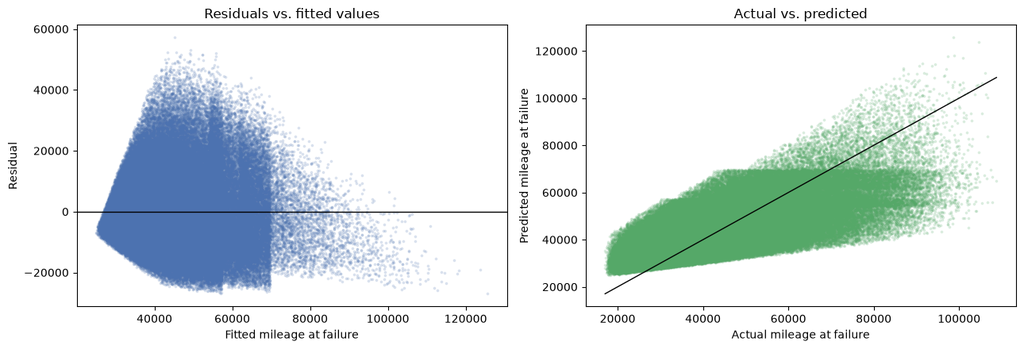

```python
fitted = model_final.fittedvalues
resid = model_final.resid

fig, axes = plt.subplots(1, 2, figsize=(13, 4.5))
axes[0].scatter(fitted, resid, s=3, alpha=0.15, color="#4C72B0")
axes[0].axhline(0, color="black", linewidth=1)
axes[0].set_xlabel("Fitted mileage at failure")
axes[0].set_ylabel("Residual")
axes[0].set_title("Residuals vs. fitted values")

axes[1].scatter(fehleranalyse["Fehlerhaft_Fahrleistung"], fitted, s=3, alpha=0.15, color="#55A868")
lims = [fehleranalyse["Fehlerhaft_Fahrleistung"].min(), fehleranalyse["Fehlerhaft_Fahrleistung"].max()]
axes[1].plot(lims, lims, color="black", linewidth=1)
axes[1].set_xlabel("Actual mileage at failure")
axes[1].set_ylabel("Predicted mileage at failure")
axes[1].set_title("Actual vs. predicted")

plt.tight_layout()
plt.show()
```

**Model:** `Fehlerhaft_Fahrleistung ≈ 20,680 + 5,235 * fuel − 3,313 * [engine=medium] − 11,160 * [engine=large]`, R² ≈ 0.48 (the model explains about 48% of the variance in mileage at failure; the rest is due to factors not captured here, such as driving conditions, usage intensity, or maintenance history).

VIF values for the actual predictors are all well below the usual concern threshold (fuel ≈ 3.0, engine=medium ≈ 2.0, engine=large ≈ 2.2) - the constant's VIF (≈ 9.5) is conventionally not interpreted for multicollinearity and is excluded from this check. This confirms no problematic multicollinearity, so the coefficients can be interpreted individually, holding the other variable constant:

- **Fuel consumption is the strongest driver:** each additional unit of `fuel` is associated with ≈ 5,235 km more mileage before failure, for a given engine size.
- **Engine size matters independently of fuel:** holding fuel consumption constant, medium engines fail ≈ 3,300 km earlier and large engines ≈ 11,160 km earlier than small engines. In other words, larger engines are systematically less mileage-robust than their fuel consumption alone would suggest.
- `days` and `Werksnummer` were not useful predictors and were dropped.

**Recommendations for OEM1:**

1. **Prioritise reliability engineering for large-engine vehicles** - they fail at substantially lower mileage than smaller engines even after accounting for fuel consumption, pointing to an engine-size-specific weak point (e.g. component wear/stress) worth investigating in the supply chain for large-engine parts.
2. **Use fuel consumption as an early monitoring signal** rather than elapsed time: since `days` has no explanatory power but `fuel` does, maintenance intervals and warranty risk models should be based on usage/consumption metrics, not calendar time.
3. **Treat this model as a starting point, not a final answer:** with R² ≈ 0.48, roughly half of the variation in failure mileage is unexplained here. Collecting additional variables (e.g. driving conditions, maintenance records, supplier batch/lot IDs) would likely improve the model and the resulting recommendations.

## 6. Hit and Run Accident Investigation (5 Points)

> On 11.08.2010, there was a hit-and-run accident. The license plate of the car involved is unknown. The police have asked for your assistance, as you work for the Federal Motor Transport Authority, to find out where the vehicle with body part number "K5-112-1122-79" was registered.

**Goal:** the body (`Karosserie`) with ID `K5-112-1122-79` needs to be traced back to the vehicle it was installed in, and that vehicle's registration municipality looked up.

**Approach:** `K5-112-1122-79` is a body/component ID, not a vehicle ID, so it cannot be looked up in the registration table directly. The vehicle-level parts lists (`Bestandteile_Fahrzeuge_OEM{1,2}_Typ{11,12,21,22}.csv`) record which body (`ID_Karosserie`) is installed in which vehicle (`ID_Fahrzeug`). Since a vehicle can only be one specific OEM/Type combination, we check all four parts-list tables for the target body ID; it can only appear in (at most) one of them. Once the matching `ID_Fahrzeug` is found, we look it up in `Zulassungen_alle_Fahrzeuge.csv` to get its registration municipality.

```python
FAHRZEUG_DIR = DATA_DIR.parent / "Fahrzeug"

comp_oem1_11 = pd.read_csv(FAHRZEUG_DIR / "Bestandteile_Fahrzeuge_OEM1_Typ11.csv", sep=";")
comp_oem1_12 = pd.read_csv(FAHRZEUG_DIR / "Bestandteile_Fahrzeuge_OEM1_Typ12.csv", sep=";")
comp_oem2_21 = pd.read_csv(FAHRZEUG_DIR / "Bestandteile_Fahrzeuge_OEM2_Typ21.csv", sep=";")
comp_oem2_22 = pd.read_csv(FAHRZEUG_DIR / "Bestandteile_Fahrzeuge_OEM2_Typ22.csv", sep=";")

target_body = "K5-112-1122-79"
parts_lists = {
    "OEM1_Typ11": comp_oem1_11,
    "OEM1_Typ12": comp_oem1_12,
    "OEM2_Typ21": comp_oem2_21,
    "OEM2_Typ22": comp_oem2_22,
}

matches = []
for name, table in parts_lists.items():
    hit = table[table["ID_Karosserie"] == target_body]
    if len(hit) > 0:
        matches.append((name, hit))
        print(f"Match found in {name}:")
        display(hit)

assert len(matches) == 1, "expected the body to appear in exactly one vehicle parts list"
matched_table_name, matched_row = matches[0]
vehicle_id = matched_row["ID_Fahrzeug"].iloc[0]
print(f"\n{target_body} was installed in vehicle {vehicle_id} ({matched_table_name})")
```

```
Match found in OEM1_Typ12:
```

|  | Unnamed: 0 | ID_Karosserie | ID_Schaltung | ID_Sitze | ID_Motor | ID_Fahrzeug |
| --- | --- | --- | --- | --- | --- | --- |
| 81 | 82 | K5-112-1122-79 | K3SG1-105-1051-129 | K2ST1-109-1092-519 | K1BE1-104-1041-409 | 12-1-12-82 |

```
K5-112-1122-79 was installed in vehicle 12-1-12-82 (OEM1_Typ12)
```

```python
result = registration[registration["IDNummer"] == vehicle_id]
display(result)

if len(result) == 1:
    city = result["Gemeinden"].iloc[0]
    reg_date = result["Zulassung"].iloc[0]
    print(f"\nVehicle {vehicle_id} (body {target_body}) was registered in {city} on {reg_date}.")
```

|  | IDNummer | Gemeinden | Zulassung |
| --- | --- | --- | --- |
| 223 | 12-1-12-82 | ASCHERSLEBEN | 2009-01-02 |

```
Vehicle 12-1-12-82 (body K5-112-1122-79) was registered in ASCHERSLEBEN on 2009-01-02 00:00:00.
```

**Result:** body `K5-112-1122-79` was installed in vehicle `12-1-12-82` (OEM1/Typ12), which was registered in **Aschersleben** on **2009-01-02**. The body ID matched exactly one of the four vehicle parts-list tables and the resulting vehicle ID matched exactly one row in the registration table, so the result is unambiguous.

**Consistency check against the full database structure:** this result lines up with what we now know about the schema. Each Karosserie (body) family is used by exactly one vehicle type - confirmed by matching row counts (`K5` has 408,096 rows, identical to `Fahrzeuge_OEM1_Typ12.csv`'s 408,096 rows) - so a `K5`-prefixed body can only ever appear in `Bestandteile_Fahrzeuge_OEM1_Typ12.csv`. That K5-112-1122-79 matched in exactly `comp_oem1_12` and nowhere else isn't a coincidence specific to this one lookup - it's the expected behaviour of the schema for *any* K5 body ID, which is good independent confirmation that the join logic is correct rather than having gotten lucky on this particular ID.